# Introducao à Manipulação de strings

Autor: Lucas Damas

Dia da publicacao: 15/07/2024

# Manipulação de Strings - Conceitos preliminares

## Introdução

Este relatório consiste em iniciar um estudo básico sobre a manipulação de palavras (strings) para conseguir efetuar algumas análises preliminares. Tal área dentro das ciências humanas tem-se tornado cada vez mais proeminente, dado que manipular grande volume de palavras manualmente era um processo extremamente cansativo até inviável. Neste estudo, usar-se-á uma base que contém todos os discursos do Jair Bolsonaro na sua época de deputado pelo rio de janeiro. Tal análise permitirá entender quais assuntos, tópicos o deputado mais pautava na plenária.

## 0. Bibliotecas utilizadas

O pacote pacman funciona tanto para carregar bibliotecas já instaladas no seu R quanto bibliotecas que não estão. Se nao tiver instalada, o pacman automaticamente instala no seu diretório.

```r
pacman::p_load(rio, tidyverse, janitor, scales, tidytext, tm, abjutils, ggwordcloud)

# especificas para manipular strings
library(tidytext)
library(tm)
library(abjutils)

# nuvem de palabras
library(ggwordcloud)
```

## 1. Base de dados

A base de dados que usaremos possui mais de 2000 discursos do ex-deputado Jair Bolsonaro durante os seus mandatos como deputado. Além de importar a base, veremos que cada observação contém uma quantidade enorme de informações.

### 1.1 Importando a base

```r
# funcao rio para importar a base
base_bozo <- import('discursos_bolsonaro.csv')

# visualizando o data frame
glimpse(base_bozo)
```

```
## Rows: 2,288
## Columns: 5
## $ discurso   <chr> "http://www.camara.leg.br/internet/sitaqweb/TextoHTML.asp?e…
## $ sumario    <chr> NA, NA, NA, NA, NA, "TRIBUNAL SUPERIOR ELEITORAL (TSE)", NA…
## $ orador     <chr> "JAIR BOLSONARO, PSL-RJ", "JAIR BOLSONARO, PSL-RJ", "JAIR B…
## $ sumario_1  <chr> "Contestação a matéria publicada pelo jornal Folha de S.Pau…
## $ discurso_1 <chr> "O SR. JAIR BOLSONARO (PSL-RJ. Sem revisão do orador.) - Sr…
```

```r
# as únicas variaveis importantes é o 'discurso_1'
discursos_bozo <- base_bozo %>%
  select(discurso = discurso_1)
```

### 1.2 Primeiro contato com a base

Nesse primeiro contato, é vísivel o enorme volume de palavras no data frame. São mais de 2000 observações, nos quais em cada uma é um discurso enorme como demonstrado no último código. Além disso, o fato de ter letras maiusculas, pontuacao e números interfere na análise de string, o que nos motivará a remover esses impecilhos.

```r
# visualizando o data frame
glimpse(base_bozo)
```

```
## Rows: 2,288
## Columns: 5
## $ discurso   <chr> "http://www.camara.leg.br/internet/sitaqweb/TextoHTML.asp?e…
## $ sumario    <chr> NA, NA, NA, NA, NA, "TRIBUNAL SUPERIOR ELEITORAL (TSE)", NA…
## $ orador     <chr> "JAIR BOLSONARO, PSL-RJ", "JAIR BOLSONARO, PSL-RJ", "JAIR B…
## $ sumario_1  <chr> "Contestação a matéria publicada pelo jornal Folha de S.Pau…
## $ discurso_1 <chr> "O SR. JAIR BOLSONARO (PSL-RJ. Sem revisão do orador.) - Sr…
```

```r
# a única variavel importantes é o 'discurso_1'
discursos_bozo <- base_bozo %>%
  select(discurso = discurso_1)

# visualizando apenas uma observaão de discurso
# analisando, só o primeiro discurso, fica vísivel a quantidade de informações contidas em somente uma observação, imagine 2000
discursos_bozo %>%
  head(1)
```

```
##                                                                                                                                                                                                                                                                                                          …
## 1 O SR. JAIR BOLSONARO (PSL-RJ. Sem revisão do orador.) - Sr. Presidente, quero falar sobre algo que a nossa Folha de S.Paulo, lamentavelmente, divulgou.\tDeputado Alberto Fraga, veja o que acabou de acontecer. Eu, como tinha dois compromissos em São Paulo, fui para o aeroporto. Quando eu já esta…
```

### 1.3 Manipulação de strings

Ao trabalhar com strings, é necessário limpar todos os textos para padronizá-los. Este processo é importante para que o software reconheca igualmente as mesmas palavras independente se tiverem com acento, caixa baixa ou não etc. Por exemplo, a palavra comissão em minúscula, comissao sem acento ou Comissao com início em maiúsculo, o R não iria reconhecer. Assim, todo esse procedimento inicial é importante para eliminar os viéses errados de interpretação.

#### 1.3.1 Caixa baixa

Primeiro passo, passar para caixa baixa as palavras

```r
discursos_bozo <- discursos_bozo %>%
  mutate(discurso = str_to_lower(discurso))
```

#### 1.3.2 Removendo pontuação e acentos

```r
discursos_bozo <- discursos_bozo %>%
  mutate(discurso = removePunctuation(discurso),
         discurso = rm_accent(discurso))
```

#### 1.3.3 Removendo números

```r
# removendo numeros
discursos_bozo <- discursos_bozo %>%
  mutate(discurso = removeNumbers(discurso))
```

#### 1.3.4 Visualizando o resultado da limpeza

```r
# visualizando a limpeza feita
discursos_bozo %>%
  head(1)
```

```
##                                                                                                                                                                                                                                                                                                          …
## 1 o sr jair bolsonaro pslrj sem revisao do orador  sr presidente quero falar sobre algo que a nossa folha de spaulo lamentavelmente divulgou\tdeputado alberto fraga veja o que acabou de acontecer eu como tinha dois compromissos em sao paulo fui para o aeroporto quando eu ja estava na regiao de em…
```

## 2. Criando data frame das palavras

A partir de agora, trabalharemos com um data frame que terá como cada observação uma palavra diferente. Tal ação agilizará o processo de analisar quais palavras mais aparecem nos discursos

### 2.1 Separando cada palavra

Observe que o novo objeto criado possui muito mais observações, já que cada palavra de cada discurso virou uma observação distinta.

```r
# separando as observações por palavras
discursos_bozo_1 <- discursos_bozo %>%
  unnest_tokens(word, discurso)

discursos_bozo_1 %>%
  slice(1:10)
```

```
##         word
## 1          o
## 2         sr
## 3       jair
## 4  bolsonaro
## 5      pslrj
## 6        sem
## 7    revisao
## 8         do
## 9     orador
## 10        sr
```

## 3. Primeiro gráfico das palavras mais correntes

### 3.1 Gráfico com stopwords

Observe que as palavras que mais aparecem são stopwords, ou seja, palavras que conectam orações e frase. Esse tipo de palavra não contribui para compreender quais os assuntos mais discutido pelo parlamentar. Logo, nós próximos tópicos iremos remover as stopwords para chegar no conteúdo relevante para a análise.

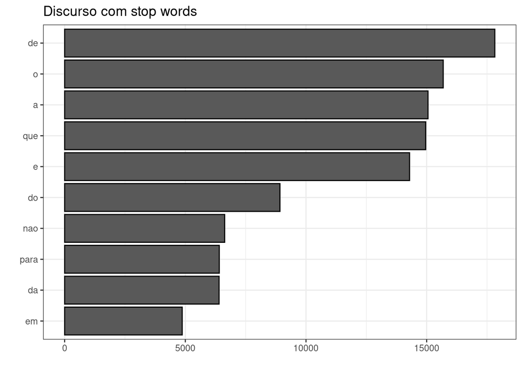

```r
# primeiro gráfico
discursos_bozo_1 %>%
  count(word) %>%
  arrange(-n) %>%
  slice(1:10) %>%
  ggplot(aes(x = reorder(word, n), y = n)) +
  geom_bar(stat = 'identity', color = 'black') +
  labs(title = 'Discurso com stop words',
       x = '',
       y = '') +
  coord_flip() +
  theme_bw()
```

```r
# usaremos esse objeto no item 6 para  comparar os dois gráficos lado a lado
graf_com_stop <- discursos_bozo_1 %>%
  count(word) %>%
  arrange(-n) %>%
  slice(1:10) %>%
  ggplot(aes(x = reorder(word, n), y = n)) +
  geom_bar(stat = 'identity', color = 'black') +
  labs(title = 'Discurso com stop words',
       x = '',
       y = '') +
  coord_flip() +
  theme_bw()
```

## 4. Removendo stopwords - 2 métodos

### 4.1 Função stopwords da biblio tm

Para remover stopwords podemos usar a função ‘stopwords’ da biblioteca ‘tm’. Esse procedimento eliminará apenas algumas stopwords, pois esse pacote é americano e não consegue reconhecer tão bem stopwords do idioma português.

```r
# criando um objeto novo, que agrupe todas as stop words
discursos_bozo_2 <- discursos_bozo_1 %>%
  count(word)

# filtrando tudo o que nao for stopwords do portugues
discursos_bozo_2 <- discursos_bozo_2 %>%
  filter(!(word %in% stopwords(kind = 'portuguese'))) %>%
  arrange(-n)

# veja que eliminou muitas stopwords, porém existem mais algumas para serem eliminadas (sr, aqui, porque)
discursos_bozo_2 %>%
  slice(1:10)
```

```
##          word    n
## 1         nao 6630
## 2          sr 3884
## 3  presidente 3399
## 4    deputado 1647
## 5   militares 1561
## 6        aqui 1394
## 7      porque 1346
## 8   bolsonaro 1297
## 9     militar 1217
## 10       jair 1205
```

### 4.2. Removendo stopwords com o chatgpt

Podemos pedir uma lista de stopwords para o chatgpt criar. Iremos pedir uma lista de stopwords pro gpt e criaremos um dataframe a parte. Com isso, usaremos a função ‘anti_join’, que vai eliminar todas as stopwords ainda existentes no objeto.

### 4.2.1 Criando um data frame com todas as stopwords

```r
# criando a lista
stopwords_pt <- c("vamos", "todos", "nós", "eles", "elas", "e", "ou", "mas",
                  "para", "por", "com", "de", "em", "no", "na", "se",
                  "que", "como", "quando", "porque", "porquê", "qual", "quem", "onde",
                  "quando", "ainda", "mais", "menos", "muito", "pouco", "bem", "mal",
                  "assim", "mesmo", "apenas", "só", "também", "ainda", "agora", "antes",
                  "depois", "enquanto", "logo", "primeiro", "segundo", "último", "sempre", "nunca",
                  "jamais", "talvez", "certamente", "provavelmente", "possivelmente", "claro", "óbvio", "absolutamente",
                  "realmente", "verdadeiramente", "efetivamente", "eficazmente", "basicamente", "principalmente", "especialmente", "particularmente",
                  "deveríamos", "precisamos", "teremos", "vamos", "devemos", "queremos", "podemos", "iremos",
                  "será", "seremos", "serão", "estamos", "estaremos", "estão", "estavam", "estiveram",
                  "havíamos", "haveremos", "haverão", "havia", "haviam", "há", "haverá", "haveriam",
                  "tínhamos", "teríamos", "teriam", "tinham", "temos", "teremos", "tiveram", "têm",
                  "tenhamos", "tenham", "teve", "tinha", "tivesse", "tenha", "tenham", "teria",
                  "tivesse", "teriam", "seja", "sejam", "sejamos", "sejamos", "fosse", "fossem",
                  "foram", "sejam", "sejamos", "fosse", "fossem", "foram", "sendo", "sido",
                  "poderia", "poderiam", "poderá", "poderão", "pode", "podem", "pôde", "puderam",
                  "puder", "pudermos", "puderem", "deve", "devem", "deveria", "deveriam", "deverá",
                  "deverão", "deveríamos", "devesse", "devessem", "dever", "deveríamos", "faz", "faça",
                  "façamos", "fazemos", "fizeram", "fazia", "fizeram", "fizerem", "fará", "farão",
                  "fazer", "fiz", "fizer", "fizeram", "fizera", "fizermos", "fizerem", "fizeria",
                  "façamos", "haja", "hajam", "hajamos", "hajam", "houve", "houveram", "havemos",
                  "houvermos", "houvesse", "houvessem", "houvesse", "haver", "haverá", "haveremos", "haverão",
                  "haveria", "haveriam", "outra", "outras", "outro", "outros", "alguma", "algumas",
                  "algum", "alguns", "muita", "muitas", "muito", "muitos", "pouca", "poucas",
                  "pouco", "poucos", "todo", "todos", "toda", "todas", "nenhum", "nenhuma",
                  "nenhuns", "nenhumas", "cada", "cada um", "cada uma", "várias", "vários",
                  "várias", "vários", "mesmo", "mesma", "mesmos", "mesmas", "próprio", "própria",
                  "próprios", "próprias", "tão", "tanta", "tantos", "tantas", "tudo", "nada",
                  "coisa", "coisas", "qualquer", "quaisquer", "todo mundo", "todos nós", "todos vocês", "cada um de nós",
                  "cada um de vocês", "ambos", "ambas", "todo o mundo", "nenhuma pessoa", "nenhuma delas", "nenhum de nós",
                  "quem quer que", "qualquer um", "alguém", "ninguém", 'nao',
                  'sr', 'presidente', 'aqui', 'orador', 'revisao', 'sao', 'ser',
                  'quero', 'bolsonaro', 'deputado', 'vai', 'ha', 'obrigado', 'militar')



# gerando um data.frame a partir da lista
stopwords_pt <- as.data.frame(stopwords_pt)
```

### 4.2.3. Editando o dataframe gerado

Para usar a função ‘anti_join’, é necessário que a coluna de referencia possua o mesmo nome. No caso, ambas devem ter o nome ‘word’

```r
# aqui renomeei a coluna para word para ficar igual nos dois objetos
stopwords_pt <- stopwords_pt %>%
  rename(word = stopwords_pt)
```

### 4.2.4. Usando a função anti join

```r
discursos_bozo_2 <- discursos_bozo_2 %>%
  anti_join(stopwords_pt, by = 'word')

discursos_bozo_2 <- discursos_bozo_2 %>%
  arrange(-n)

discursos_bozo_2 %>%
  slice(1:10)
```

```
##         word    n
## 1  militares 1561
## 2       jair 1205
## 3    governo 1192
## 4       <NA> 1184
## 5       casa 1121
## 6       anos 1111
## 7     forcas 1098
## 8    armadas 1001
## 9     tambem  986
## 10    brasil  903
```

## 5. Gráfico sem stopwords

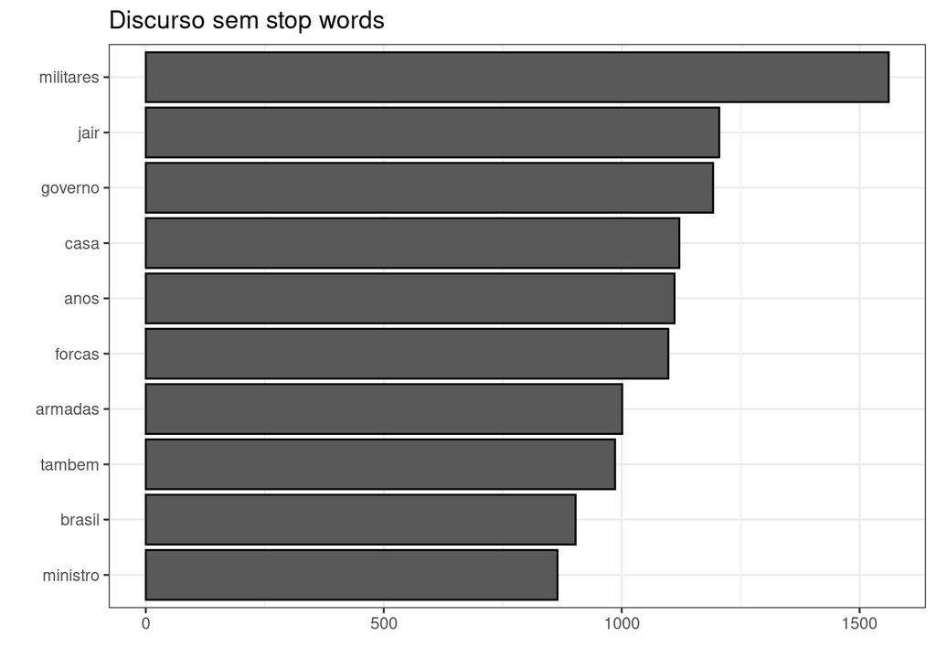

```r
discursos_bozo_2 %>%
  filter(!is.na(word)) %>%
  slice(1:10) %>%
  ggplot(aes(x = reorder(word, n), y = n)) +
  geom_bar(stat = 'identity', color = 'black') +
  coord_flip() +
  theme_bw() +
  labs(title = 'Discurso sem stop words',
       x  = '',
       y = '')
```

```r
# usaremos esse objeto no item 6 para  comparar os dois gráficos lado a lado
graf_sem_stop <- discursos_bozo_2 %>%
  filter(!is.na(word)) %>%
  slice(1:10) %>%
  ggplot(aes(x = reorder(word, n), y = n)) +
  geom_bar(stat = 'identity', color = 'black') +
  coord_flip() +
  theme_bw() +
  labs(title = 'Discurso sem stop words',
       x  = '',
       y = '')
```

## 6. Comparação dos resultados

Analisando ambos os gráficos, fica vísivel como tratar strings é fundamental para conseguir analisar palavras em qualquer software de programação. Nesse caso, usamos funcoes para padronizar todas as palavras e aprendemos dois métodos de remover stopwords da base de dados

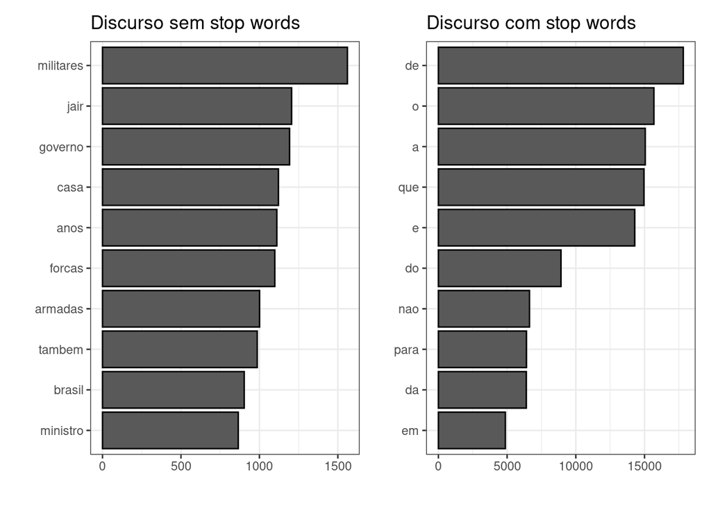

```r
# biblioteca para visualizar graficos simultaneamente
library(patchwork)

# 'somando' os gráficos
graf_sem_stop+graf_com_stop
```

## 7. Nuvem de palavras

Embora seja limitada para análises quantitativas, a nuvem de palavras permite observar de maneira dinamica quais assuntos mais aparecem no discurso parlamentar. É uma ótima ferramenta para abordar o conteúdo em um seminário por exemplo.

### 7.1. Pacote ggwordcloud

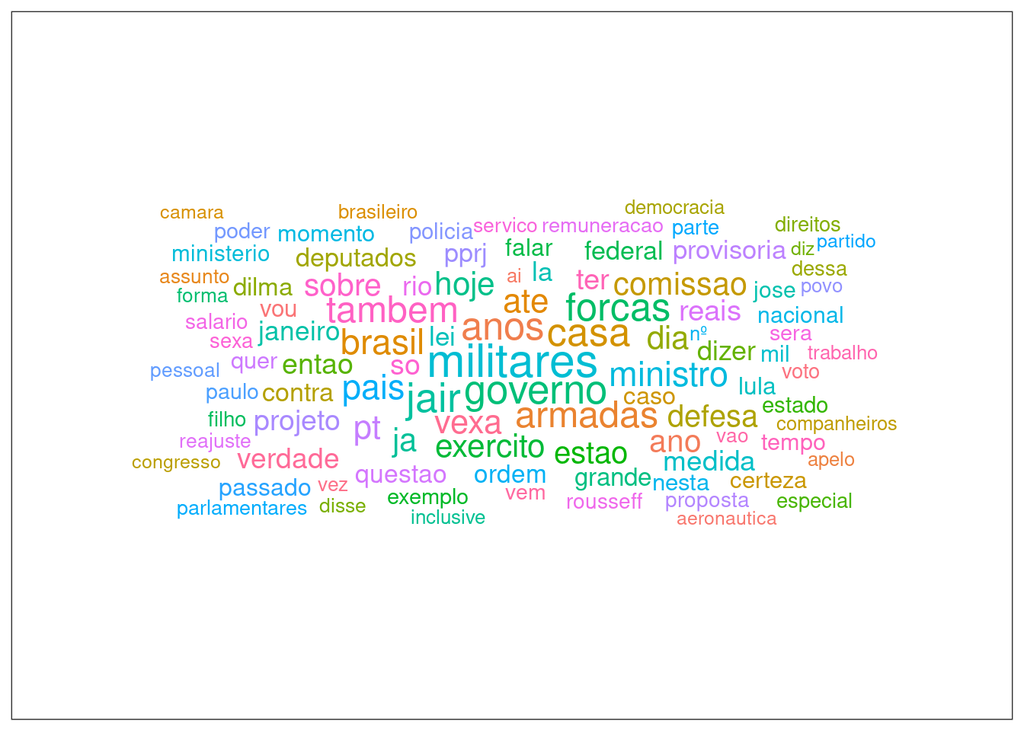

```r
library(ggwordcloud)

discursos_bozo_2 %>%
  slice(1:100) %>%
  arrange(-n) %>%
  ggplot(aes(label = word, size = 2*n, color = word)) +
  geom_text_wordcloud(rm_outside = T, shape = 'square') +
  theme_bw() +
  scale_size_area(max_size = 8)
```

## 8. Conclusão

Tratar strings é um novo campo da sociais, possibilitando uma série de análises que até então necessitavam de um tempo longo e trabalhoso para ser feito. Tal trabalho foi apenas uma síntese do assunto. Consulte bibliotecas como ‘rslp’ e ‘SnowBallC’ para aprimorar mais no assunto, por exemplo, eliminando palavras com o mesmo radical.